# Introduction à R - s1

31/05/2024

[figure not shown]

[figure not shown]

**L’utilisation :**

Ce document est préparé pour le workshop de R de CERMO-FC. Vous êtes libre de partager et d’utiliser ce matériel, mais veuillez citer la source.

## Langage de programmation R

R se compose de 2 éléments :

1. Le logiciel lui-même et ses packages de base.
2. Des packages supplémentaires (ou “bibliothèques”) qui peuvent être installés séparément et apporter des fonctionnalités supplémentaires.

## Installation

#### Télécharger R :

Voir le lien (https://www.r-project.org) pour télécharger R

#### Installation de R sur Linux (Debian ou Ubuntu) :

```
sudo apt update
sudo apt install r-base r-base-dev
```

## RStudio :

RStudio est une interface qui facilite l’utilisation des outils utilisés. Il nécessite le téléchargement préalable du logiciel R. Voici le lien (https://www.rstudio.com/products/rstudio/download/) pour télécharger RStudio

Lorsque vous ouvrez RStudio pour la première fois, vous voyez trois panneaux :

- La console interactive R, plusieurs paragraphes suivis du prompt de commande ‘>’ (à gauche)
- Environnement/Historique, où sont répertoriées les données et leurs principales caractéristiques (onglets en haut à droite)
- En bas à droite, la fenêtre vous permet d’afficher vos fichiers, graphiques et packages utilisés ou d’obtenir de l’aide .

[figure not shown]

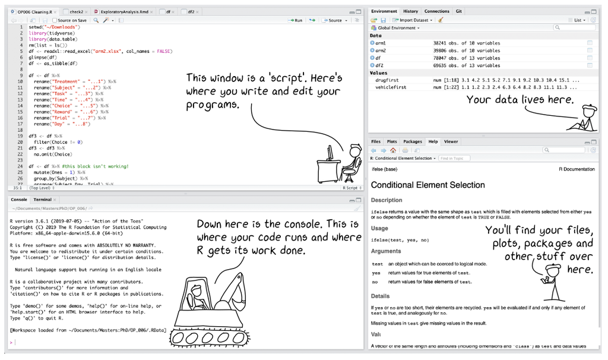

L’interface RStudio : https://r-unimelb.gitbook.io/rbook/introduction-to-r-and-rstudio/introduction-to-rstudio

**Suggestion :** Écrivez vos commandes dans un fichier avec l’extension *.r* pour deux raisons :

1. Ne perdez pas les codes et les commandes que vous avez utilisés pour votre analyse
2. Vous pouvez exécuter toutes vos commandes en exécutant le fichier *.r* (nous le verrons plus tard)

### R comme une calculatrice :

Toutes les opérations habituelles peuvent être effectuées avec R :

```r
2 + 2
```

```
## [1] 4
```

```r
# exponentielle
2 ^ 5
```

```
## [1] 32
```

```r
# modulo ou reste
4 %% 3
```

```
## [1] 1
```

```r
5 %% 3
```

```
## [1] 2
```

```r
# logarithme népérien (log base e, 2,71828)
log(12)
```

```
## [1] 2.484907
```

```r
# log base 10
log10(10)
```

```
## [1] 1
```

```r
# pi
pi
```

```
## [1] 3.141593
```

```r
# valeur arrondie entier qui n'est pas inférieur à la valeur elle-même
ceiling(pi)
```

```
## [1] 4
```

```r
ceiling(c(3, 4.5, 5.7894, 9.15, -2.5, -7.36, -9.87))
```

```
## [1]  3  5  6 10 -2 -7 -9
```

```r
# valeur arrondie entier qui n'est pas supérieur à la valeur elle-même
floor(pi)
```

```
## [1] 3
```

```r
floor(c(3, 4.5, 5.7894, 9.15, -2.5, -7.36, -9.87))
```

```
## [1]   3   4   5   9  -3  -8 -10
```

```r
# arrondi en tenant compte du nombre de décimales
round(pi, 3)
```

```
## [1] 3.142
```

```r
# renvoie la valeur avec 5 chiffres après la virgule
round(pi, 5)
```

```
## [1] 3.14159
```

## Variables

En informatique, une variable est représentée par un symbole (l’identifiant) et est associée à une valeur.  
Une variable peut changer de valeur au fil du temps (dynamique).

**Attention :** Tous les langages de programmation ont un ensemble de mots réservés qu’il faut éviter lors de la nomination de nos variables.

### Choix d’un nom pour la variable

Pour pouvoir manipuler le résultat d’une fonction et l’intégrer dans des calculs, il est nécessaire de le stocker dans un objet auquel nous donnons un nom (c’est ce qu’on appelle l’assignation). Nous devons faire attention à la façon dont nous nommons les variables et nous assurer que les noms ont toujours un sens.

**Attention :** Ce qu’il est fortement conseillé de faire :

1. Le nom de la variable doit être informatif et court.
2. Le nom de la variable ne doit pas commencer par des chiffres('1', '0', '2', etc.).
3. Les noms de variables d’un seul caractère doivent être évités sauf pour les variables temporaires “jetables” ou les compteurs dans les boucles.
4. Vous devez éviter les mots réservés du langage pour nommer les variables. Exemple : class, colname, rowMeans, data.frame, mean, rbind, ….
5. Les espaces ne doivent pas être utilisés dans les noms de variables.
6. Utilisez “_” ou simplifiez le nom si possible. Ce sera toujours plus facile à gérer par la suite. Exemple: "oxygConc" au lieu de "oxygen concentrations".
7. Il vaut mieux éviter les accents et autres caractères spéciaux (surtout ceux utilisés par le logiciel: °C, %, #, $) dans le nom des variables, des lignes et des colonnes, par exemple: 'temperature' au lieu de 'température'

### Affectation de variable

En R, vous pouvez affecter une variable de deux manières : x *<-* 2, x *=* 2

```r
x <- 2
y = 4.0
X = 23
X == x  # Ce n'est pas une affectation. C'est une comparaison
```

```
## [1] FALSE
```

### Types de variables de base :

numérique : 2, 5, 3.2  
caractère : 'a', '3'  
chaîne de caractères : "Hello world"  
booléen : True, False

En R, les types de variables ‘caractère’ et ‘chaîne de caractères’ sont la même chose.

```r
longGene = 3200
longGene
```

```
## [1] 3200
```

```r
class(longGene)
```

```
## [1] "numeric"
```

```r
nomGene1 = "INS"
nomGene1
```

```
## [1] "INS"
```

```r
class(nomGene1)
```

```
## [1] "character"
```

```r
ensmblTSV = "files/GCF_000002285_ensmbl.tsv"
ensmblTSV
```

```
## [1] "files/GCF_000002285_ensmbl.tsv"
```

```r
class(ensmblTSV)
```

```
## [1] "character"
```

```r
timePoint = '3'
timePoint
```

```
## [1] "3"
```

```r
class(timePoint)
```

```
## [1] "character"
```

```r
geneIsDE = TRUE
geneIsDE
```

```
## [1] TRUE
```

```r
class(geneIsDE)
```

```
## [1] "logical"
```

Si nous mettons la variable seule sur le terminal de R, elle affiche sa valeur.

```r
geneID = 'HLA-A'
geneID
```

```
## [1] "HLA-A"
```

```r
print(geneID)
```

```
## [1] "HLA-A"
```

```r
a = 3
b = 6
Sum = a + b
Sum
```

```
## [1] 9
```

## Structures de données

En informatique, nous stockons un ensemble de données de manière structurée pour les traiter plus facilement.

Une structure de données est un format spécialisé pour organiser, traiter, récupérer et stocker des données.

### Vecteurs

Ensemble de valeurs du même type. Un vecteur peut être numérique, caractère ou autre.

La fonction `c()` en R est utilisée pour *combiner* ou concaténer les valeurs.

Exemple, si vous voulez conserver les conditions associées à vos échantillons :

```r
listCond = c('control','treated1', 'treated2','treated3')
listCond
```

```
## [1] "control"  "treated1" "treated2" "treated3"
```

```r
class(listCond)
```

```
## [1] "character"
```

```r
listGeneLen  = c(3200, 11563, 480)
listGeneLen
```

```
## [1]  3200 11563   480
```

```r
class(listGeneLen )
```

```
## [1] "numeric"
```

**Indexage**

En R, le premier élément d’une liste ou d’un vecteur est indexé par 1. La figure suivante montre une représentation de l’espace mémoire qui stocke un ensemble de nombres dans le vecteur *`lsNumber`* :

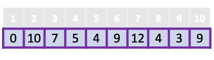

Pour accéder aux éléments de notre vecteur par leurs indices, nous devons utiliser les crochets `"[]"`.

```r
lsNumber = c(0,10,7,5,4,9,12,4,3,9)
```

Quelle est la taille du vecteur ?

```r
length(lsNumber)
```

```
## [1] 10
```

Que produisent les exemples suivants ?

```r
lsNumber[2]
```

```
## [1] 10
```

```r
lsNumber[4]
```

```
## [1] 5
```

```r
lsNumber[18]
```

```
## [1] NA
```

Nous pouvons également avoir accès à plusieurs éléments qui se suivent de la manière suivante :

```r
lsNumber[2:8]
```

```
## [1] 10  7  5  4  9 12  4
```

Que pensez-vous que les lignes suivantes produiront ?

```r
listeGene = c("NBR1", "1A13B", "KIAA0049", "M17S2", "MIG19")
listeGene[3]
```

```r
listeGene[2:4]
```

### Factors

*Les Factors* sont des objets de données qui servent à catégoriser les données et à les stocker par niveaux. Ils sont utiles dans les colonnes qui ont un nombre limité de valeurs uniques, comme “Homme, Femme” et Vrai, Faux, etc. Ils sont utiles dans l’analyse de données pour la modélisation statistique.

Les facteurs sont créés en utilisant la fonction `factor()` en prenant un vecteur comme entrée :

```r
# Créer un vecteur
data <- c('control','treated','control','treated','control','treated')
print(data)
```

```
## [1] "control" "treated" "control" "treated" "control" "treated"
```

```r
print(is.factor(data))
```

```
## [1] FALSE
```

```r
# Appliquer la fonction factor()
factor_data <- factor(data)
print(factor_data)
```

```
## [1] control treated control treated control treated
## Levels: control treated
```

```r
print(is.factor(factor_data))
```

```
## [1] TRUE
```

### Listes

*Les listes* sont des objets R qui contiennent des éléments de différents types tels que des nombres, des chaînes de caractères, des vecteurs et une autre liste à l’intérieur. Pour créer une liste, utilisez la fonction `list()` en R :

```r
list_data1 <- list("gene", "protein", c(21,32,11), TRUE, 51.23, 119.1)
print(list_data1)
```

```
## [[1]]
## [1] "gene"
##
## [[2]]
## [1] "protein"
##
## [[3]]
## [1] 21 32 11
##
## [[4]]
## [1] TRUE
##
## [[5]]
## [1] 51.23
##
## [[6]]
## [1] 119.1
```

Créer une liste contenant un vecteur, un booléen et une liste :

```r
list_data <- list(c("CMV","HIV","HPV"), TRUE, list("HLA-B",12.3))
```

Attribuer des noms aux éléments de la liste :

```r
names(list_data) <- c("virus", "isPos", "geneExp")
# Afficher la liste
print(list_data)
```

```
## $virus
## [1] "CMV" "HIV" "HPV"
##
## $isPos
## [1] TRUE
##
## $geneExp
## $geneExp[[1]]
## [1] "HLA-B"
##
## $geneExp[[2]]
## [1] 12.3
```

Accéder aux éléments de la liste par index :

```r
list_data[1]
```

```
## $virus
## [1] "CMV" "HIV" "HPV"
```

Accéder aux éléments de la liste par nom :

```r
list_data["virus"]
```

```
## $virus
## [1] "CMV" "HIV" "HPV"
```

```r
list_data$isPos
```

```
## [1] TRUE
```

Pour accéder aux éléments dans une liste de liste :

```r
# élément de la liste de cette liste
list_data[["virus"]][[2]]
```

```
## [1] "HIV"
```

```r
# élément de la liste de liste
list_data[[]][[]]
```

## Fonctions

Une fonction est un ensemble d’instructions organisées pour effectuer une tâche spécifique. R dispose d’un grand nombre de fonctions intégrées et l’utilisateur peut créer ses propres fonctions.

La fonction, à son tour, exécute sa tâche, ses résultats peuvent être stockés dans d’autres objets.

Une fonction R est créée en utilisant le mot-clé *function*. La syntaxe de base de la définition d’une fonction R est la suivante :

```r
funcName  <- function(arg_1, arg_2, ...) {
  <instructions>
  return()
}
```

Les différentes parties d’une fonction sont les suivantes :

1. *Nom de la fonction* : Il s’agit du véritable nom de la fonction. Il est stocké dans l’environnement R sous ce nom.
2. *Arguments* : Un argument est un espace réservé. Lorsqu’une fonction est invoquée, vous passez une valeur à l’argument. Les arguments sont facultatifs, c’est-à-dire qu’une fonction peut ne pas contenir d’arguments. Les arguments peuvent également avoir des valeurs par défaut.
3. *Corps de la fonction* : Le corps de la fonction contient un ensemble d’instructions qui définissent ce que la fonction fait.
4. *Valeur de retour* : La valeur de retour d’une fonction est la dernière expression dans le corps de la fonction.

#### Fonctions intégrées en R

R dispose de nombreuses fonctions intégrées qui peuvent être appelées directement dans le programme sans avoir à les définir au préalable. Par exemple : `mean()`, `min()`, `max()`, `print()`, `paste()`, `length()`, `sum()`, etc.

Nous pouvons également créer et utiliser nos propres fonctions.

```r
# Créer une séquence de nombres de 30 à 46
mySeq = seq(30,46)
mySeq
```

```
##  [1] 30 31 32 33 34 35 36 37 38 39 40 41 42 43 44 45 46
```

```r
# Trouver la moyenne des nombres de 10 et 11
myMean = mean(c(10,11))
myMean
```

```
## [1] 10.5
```

```r
# Trouver la moyenne des nombres de 9 à 13
myMean2 = mean(9:13)
myMean2
```

```
## [1] 11
```

```r
# Afficher la somme des nombres de 10 et 20
print(sum(10,20))
```

```
## [1] 30
```

```r
# Afficher la somme des nombres de 1 à 5
print(sum(1:5))
```

```
## [1] 15
```

#### Appels de fonction

```r
maFonction(arg1, arg2)
```

```r
seq(10, 25)
```

```
##  [1] 10 11 12 13 14 15 16 17 18 19 20 21 22 23 24 25
```

Appeler une fonction avec les valeurs des arguments par nom

```r
seq(to = 10, from = 1)
```

```
##  [1]  1  2  3  4  5  6  7  8  9 10
```

Quelle est la différence entre les trois commandes suivantes ?

```r
seq(1,10)
seq(10,1)
seq(to = 10, from = 1)
```

#### Utilisation de la fonction *help()* de R

```r
help(seq)
```

```r
?seq
```

#### Quelques fonctions importantes pour les vecteurs

*length()*

```r
length(mySeq)
```

```
## [1] 17
```

*c()*  
Les valeurs non caractères sont converties en caractères si l’un des éléments est un caractère :

```r
s <- c('gene','mRNA',5,TRUE)
print(s)
```

```
## [1] "gene" "mRNA" "5"    "TRUE"
```

*sort()*

```r
print(s)
```

```
## [1] "gene" "mRNA" "5"    "TRUE"
```

```r
print(sort(s))
```

```
## [1] "5"    "gene" "mRNA" "TRUE"
```

```r
print(lsNumber)
```

```
##  [1]  0 10  7  5  4  9 12  4  3  9
```

```r
sort(lsNumber)
```

```
##  [1]  0  3  4  4  5  7  9  9 10 12
```

```r
sort(lsNumber, decreasing = TRUE)
```

```
##  [1] 12 10  9  9  7  5  4  4  3  0
```

*rep()*

```r
rep(3, 5)
```

```
## [1] 3 3 3 3 3
```

## Prise de décision et opérations logiques

La prise de décision est une partie importante de la programmation. Cela peut être fait en programmation R en utilisant l’instruction conditionnelle `if...`, `if...else`, `if...else if...else`.

Les opérateurs relationnels (de comparaison) peuvent être utilisés pour tester si une condition particulière est vraie ou fausse.

Si l’expression est *TRUE*, l’instruction est exécutée. Mais si elle est *FALSE*, dans le cas de `if...` rien ne se passe, alors que pour `if...else`, la deuxième condition est appliquée. De plus, si nous avons plusieurs conditions à vérifier, nous pouvons les vérifier également avec `if...else if...else`.

Dans le cas d’un vecteur numérique, zéro est considéré comme *FALSE*, le reste comme *TRUE*.

```r
a = 2
b = 3
a == b
```

```
## [1] FALSE
```

```r
b != a  # négation
```

```
## [1] TRUE
```

```r
a < b # a est plus petit que b, exclusivement
```

```
## [1] TRUE
```

```r
b <= a # b est plus petit que et incluant a
```

```
## [1] FALSE
```

```r
b < b
```

```
## [1] FALSE
```

### Vérifier plusieurs conditions en même temps

Par exemple, pour décider si on va au travail demain, il faut qu’un ensemble des conditions soient vraies. Si demain est un jour différent que samedi et dimanche, et qu’on n’est pas malade et ce n’est pas un jour férié.

On va au travail si la condition suivante est VRAIE : (ce n’est pas la fin de semaine) **ET** (on n’est pas malade) **ET** (ce n’est pas un jour férié)

(jour est lun **OU** jour est mar **OU** jour est mer **OU** jour est jud **OU** jour est ven) **ET** (n’est pas malade) **ET** (jour n’est pas dans les jours fériés)

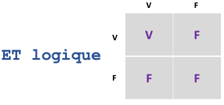

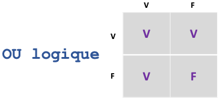

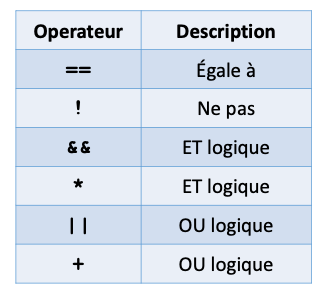

Exemples d’opérations logiques :

```r
TRUE + FALSE
```

```
## [1] 1
```

```r
TRUE + TRUE
```

```
## [1] 2
```

```r
FALSE + FALSE
```

```
## [1] 0
```

```r
FALSE + TRUE + FALSE + FALSE + FALSE
```

```
## [1] 1
```

```r
TRUE + 1
```

```
## [1] 2
```

```r
FALSE & FALSE
```

```
## [1] FALSE
```

```r
FALSE | 1
```

```
## [1] TRUE
```

```r
TRUE | 1
```

```
## [1] TRUE
```

```r
FALSE & 1
```

```
## [1] FALSE
```

```r
FALSE & 0
```

```
## [1] FALSE
```

```r
TRUE & 0
```

```
## [1] FALSE
```

```r
1 != 2
```

```
## [1] TRUE
```

```r
3 >= 2 & 3 < 10
```

```
## [1] TRUE
```

**Note:**

L’opérateur `&` effectue des comparaisons élément par élément de la même manière que les opérateurs arithmétiques et son résultat est vectorisé. L’opérateur `&&` évalue de gauche à droite en ne regardant que le premier élément de chaque vecteur. L’évaluation se poursuit uniquement jusqu’à ce que le résultat soit déterminé. La forme longue est appropriée pour la programmation de flux de contrôle. `|` et `||` ont la même différence que ci-dessus.

Dans la dernière version de R, si nous appliquons  
`&&`ou `||` à un vecteur, cela génère une  
erreur. On ne peut les appliquer qu’à une seule variable.

```r
a = c(TRUE, TRUE, FALSE, FALSE)
b = c(TRUE, FALSE, TRUE, FALSE)

a | b
```

```
## [1]  TRUE  TRUE  TRUE FALSE
```

```r
a || b
```

Quel est le résultat de ces comparaisons ?

```r
z = 0

TRUE || z
FALSE && z

TRUE | z
FALSE & z
```

## Fin de la session 1

**Références:**

Ce document est basé sur les notes de cours “Course_1_intro_R” (préparé par Golrokh Kiani) ainsi que sur du matériel gratuit sur internet:

https://www.tutorialspoint.com  
https://scilifelab.github.io/courses/r_programming/1611/Exercises/Vectors  
https://www.r-exercises.com  
https://www.datamentor.io/r-programming/  
https://training.computeontario.ca  
https://www.w3schools.com/  
http://www.r-tutor.com/